# Review of centrality measures in weighted networks

Elsa Arcaute

3rd February 2020

# Centrality

Nodes within a network can play different roles and have different levels of importance. Centrality measures help determine what these roles are. In this sense, a single measure cannot capture “importance”, since this is determined with respect to a specific situation/problem at hand. For example, a person might be very important in leading a group of people, but very bad at mediating conflict bewtween groups, and a different member of the community might be needed for this role. In general, one finds division of roles. We aim at identifying these roles through centrality measures in networks.

Some examples of centrality measures are:

- Degree centrality
- Eigenvector centrality
- Katz Centrality
- Closeness centrality
- Betweeness centrality

See lectures for the definitions. Within this section we will review degree, closeness and betweenness centrality.

For clarity we will use an example of a made-up social network. I asked my then 8 years old son Yaan to construct a small immediate network of people important for his dad. How? build a list of person 1| person 2| weight, where the weight is a number between 1 and 10 relating to the importance of the relationship, 10 being the highest.

```r
#file constructed by Yaan
file_network <- "network_dad.csv"

#read and get network
dat=read.csv(file_network,header=TRUE)
head(dat)
```

```
##     node1 node2 weight
## 1    Yaan   dad     10
## 2    Yaan   mum     10
## 3    Yaan   Abu     10
## 4     mum   Abu     10
## 5     dad   Abu      9
## 6 friendM  Yaan     10
```

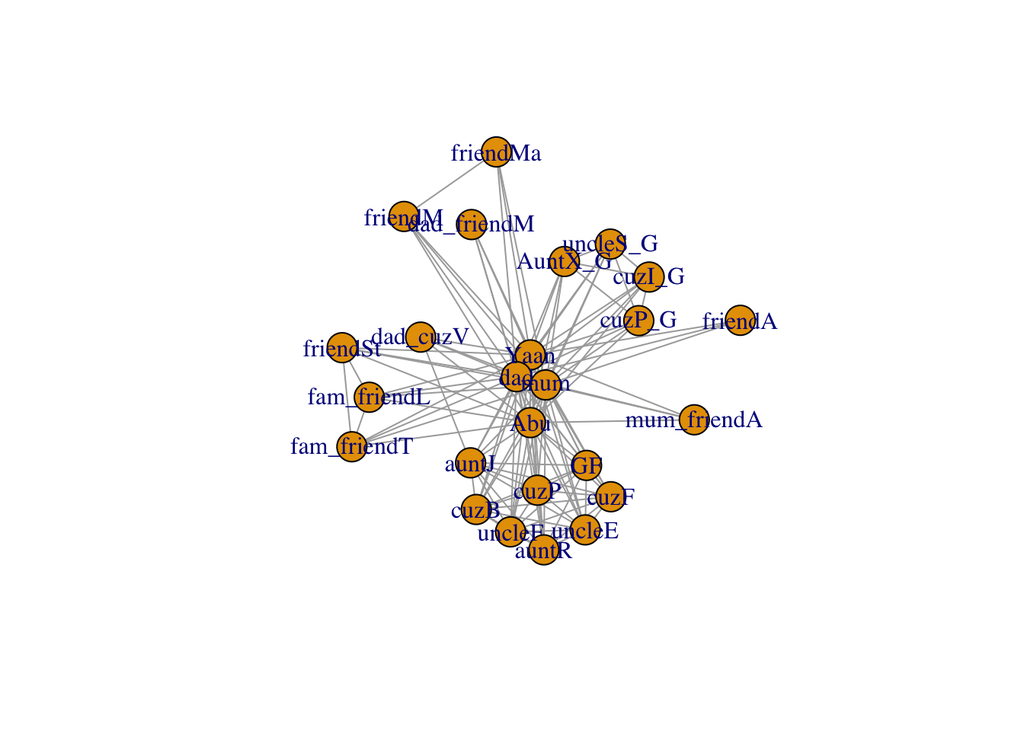

```r
g_dad=graph.data.frame(dat,directed=FALSE)

#let us plot it
plot(g_dad)
```

Plotting the network in this way does not give us enough information. Let us compute some centrality measures and make sense of this network.

**Degree centrality**

The degree of a node refers to the number of links connected to it. Let us plot the network again including this new piece of information:

```r
#Let us compute the degree centrality
deg_dad=degree(g_dad, v=V(g_dad), loops = F, normalized = FALSE)

print(deg_dad)
```

```
##        Yaan         mum         dad     friendM    dad_cuzV        cuzF
##          24          23          23           5           5          11
##          GF        cuzB      cuzI_G      cuzP_G     AuntX_G        cuzP
##          11          11           7           7           7          11
##       auntR      uncleF      uncleE       auntJ     friendA mum_friendA
##          11          11          11          12           3           4
##    uncleS_G dad_friendM fam_friendL fam_friendT    friendSt    friendMa
##           7           4           6           6           6           4
##         Abu
##          22
```

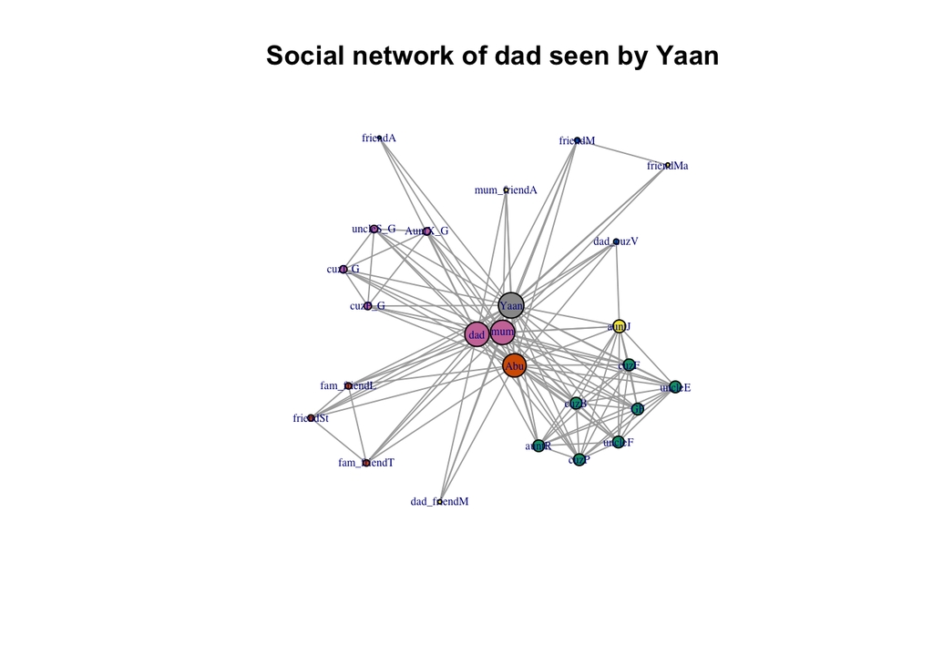

```r
#we can plot the graph using the measure of degree
plot(g_dad,vertex.size=deg_dad/max(deg_dad)*14,vertex.color=deg_dad,vertex.label.cex=0.5)
title(main = "Social network of dad seen by Yaan")
```

In this plot we can see who is the most connected person, any surprises?

Now recall the previous section in which you learnt that there’s ‘in’ and ‘out’ degree. Who is more important?

What if instead of looking at the *number* of connections you have, you look at how important those connections are? –> **Eigenvector centrality** More elaborated algorithms looking at not only the importance of the connections, but at the connections pointing *to you*, etc, are the ones used to rank internet pages for example, such as **Page Rank**.

**Closeness centrality**

Let $d_{ij}$ be the geodesic distance (shortest path) between node $i$ and $j$. The mean geodesic distance of node $i$ to all other nodes is given by:
$$l_{i} = \frac{1}{n}\sum_{j}d_{ij}$$
where $n$ is the total number of nodes.

A node that is very *close* to most nodes, and has hence low mean geodesic, will be more influential than a node which is far away. This gives rise to the following definition for the closeness centrality of node $i$:
$$C_{i} = \frac{1}{l_{i}} = \frac{n}{\sum_{j}d_{ij}}$$

Let us compute the closeness centrality for each node in dad’s network. Note that when using a software, it is important that you always read the documentation, since for example, in the case of iGraph in R, if not specified, the measure is not divided by the total n. of nodes. If normalised it will be normalised by $n-1$.

The link to the documentation is here: https://igraph.org/r/doc/closeness.html

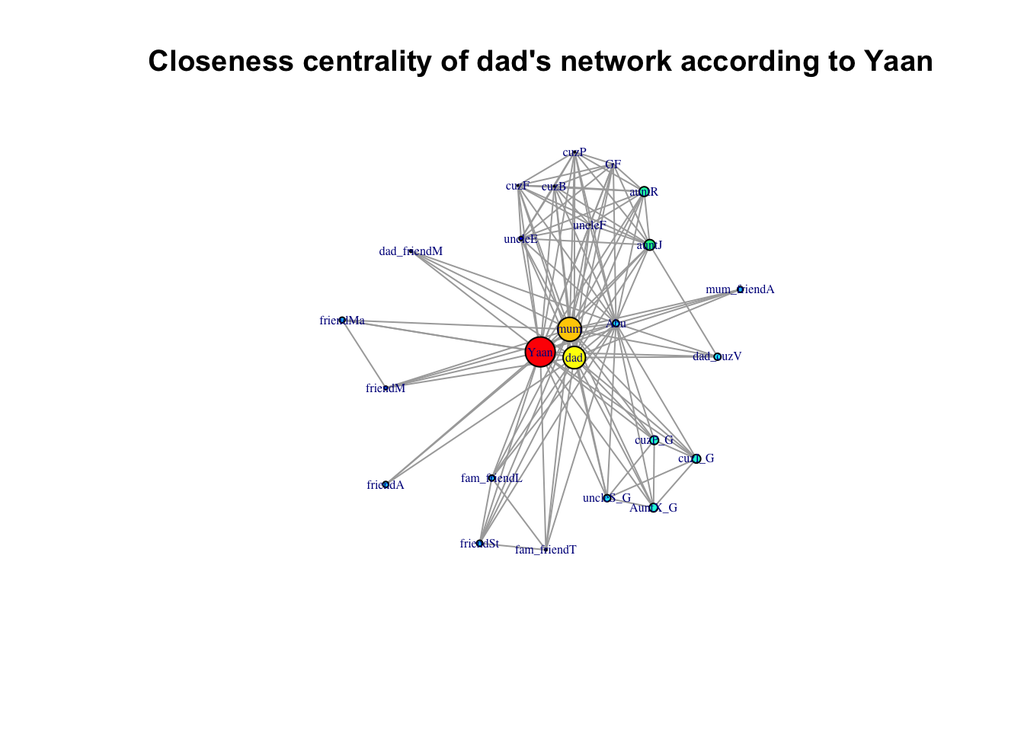

```r
# given that the network is weighted let us introduce the weights.
v_weights=1/(E(g_dad)$weight)

# Note that we inverted the weights, since they are meant to represent a distance.
# the higher the value to closer they are
clos_dad=closeness(g_dad,weights = v_weights)

# the following two commands are just to choose colours for the nodes, a palette
normalised_clos_dad=(clos_dad-min(clos_dad))/(max(clos_dad)-min(clos_dad))
palette=hsv(h=1-((normalised_clos_dad*2/3)+1/3),s = 1,v=1)

# Not we can plot it
plot(g_dad,vertex.color=palette,vertex.size=normalised_clos_dad*15,vertex.label.cex=.5)
title(main = "Closeness centrality of dad's network according to Yaan")
```

And now who is the most important person in the network according to closeness centrality? Is this surprising?

The measure computed above took into account the weights of the network. This means that the distance between two nodes that are not connected, might be shorter than the distance between two nodes that are connected but have very low “friendship” number. If this is disregarded, the measure only corresponds to the shortest path computed according to the number of links between them.

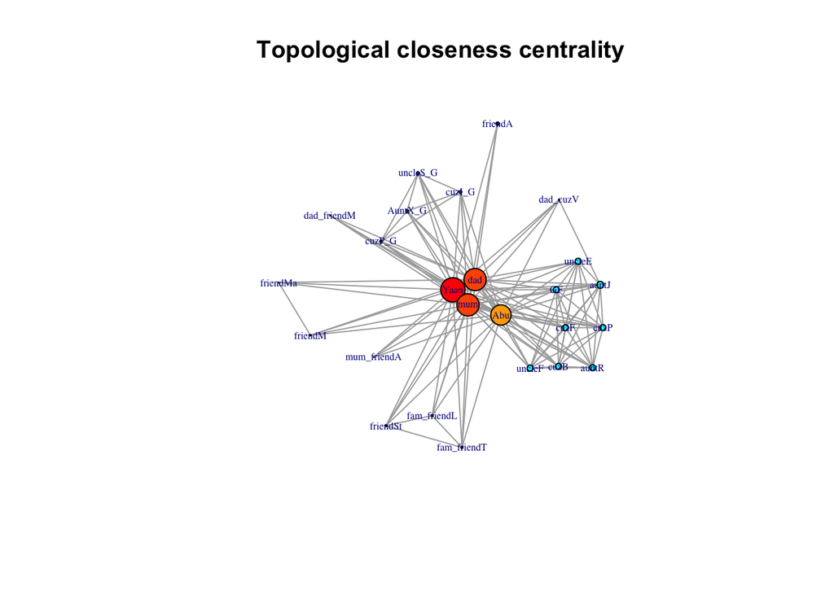

```r
#topological closeness
clos_top_dad=closeness(g_dad, weights = NA)
normalised_clos_top_dad=(clos_top_dad-min(clos_top_dad))/(max(clos_top_dad)-min(clos_top_dad))
palette_top=hsv(h=1-((normalised_clos_top_dad*2/3)+1/3),s = 1,v=1)
plot(g_dad,vertex.color=palette_top,vertex.size=normalised_clos_top_dad*15,vertex.label.cex=.5)
title(main = "Topological closeness centrality")
```

**Betweenness centrality**

The betweenness centrality of a vertex corresponds to the number of shortest paths passing through it among all pairs. Edge betweennness is defined in a similar, where the edge is within the shortest path.

Define $n^{i}_{st}$ as:
$$n^{i}_{st} = \begin{cases} 1, & \text{if vertex }i\text{ lies on the geodesic path from }s\text{ to }t\\
0, & \text{otherwise}
\end{cases}$$

Then betweenness centrality can be defined as:
$$x_{i} = \sum_{st}n^{i}_{st}$$

However, there may be multiple geodesics from $s$ to $t$ so to account for this we normalise by the number of geodesics from $s$ to $t$, $g_{st}$:
$$x_{i} = \sum_{st}\frac{n^{i}_{st}}{g_{st}}$$

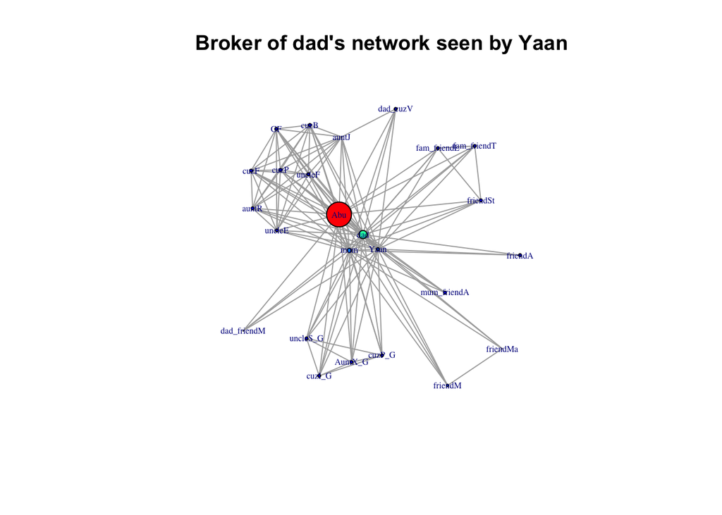

```r
#Let us compute the betweenness centrality for the network
bet_dad=betweenness(g_dad, v=V(g_dad), directed = F, normalized = FALSE, weights = (E(g_dad)$weight))
palette=hsv(h=1-((bet_dad/max(bet_dad)*2/3)+1/3),s = 1,v=1)
plot(g_dad,vertex.color=palette,vertex.size=bet_dad/max(bet_dad)*18,vertex.label.cex=.5)
title(main = "Broker of dad's network seen by Yaan")
```

This is a rather nice result: the grandma is the broker of the system!

Note that such a nice result fooled us.

**Exercise:** find why this result is incorrect, and what would you change to find the correct one.

Let us look at the topological betweenness and see whether we get any insights:

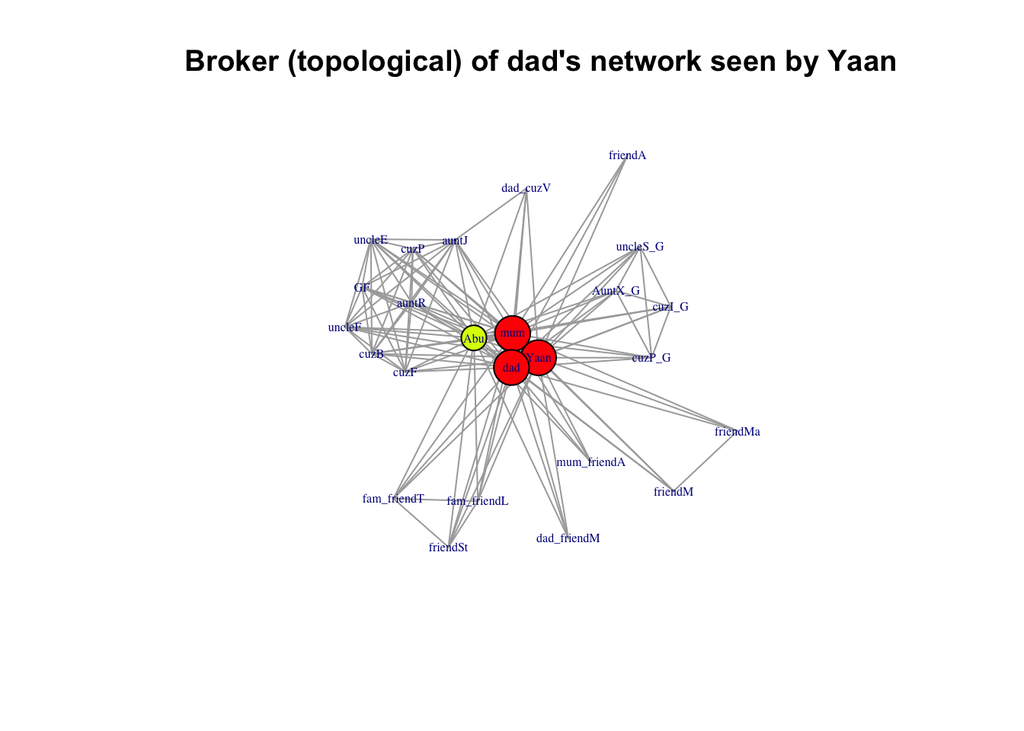

```r
#Topological betweenness centrality for the network
bet_dad_top=betweenness(g_dad, v=V(g_dad), directed = F, normalized = FALSE, weights = NA)
palette_top=hsv(h=1-((bet_dad_top/max(bet_dad_top)*2/3)+1/3),s = 1,v=1)
plot(g_dad,vertex.color=palette_top,vertex.size=bet_dad_top/max(bet_dad_top)*18,vertex.label.cex=.5)
title(main = "Broker (topological) of dad's network seen by Yaan")
```

There are 2 lessons to learn from this:

- assigning arbitrary numbers to relationships can lead to misleading results
- we need to be careful when using weights: what are they encoding? how are they representing the system? how can we integrate them correctly?